# Homework 4

```r
Data<-read.csv("titanic.csv")
head(Data)
```

```
##   pclass survived Residence                             name age sibsp parch
## 1      3        0         0              Abbing, Mr. Anthony  42     0     0
## 2      3        0         0    Abbott, Master. Eugene Joseph  13     0     2
## 3      3        0         0      Abbott, Mr. Rossmore Edward  16     1     1
## 4      3        1         0 Abbott, Mrs. Stanton (Rosa Hunt)  35     1     1
## 5      3        1         2      Abelseth, Miss. Karen Marie  16     0     0
## 6      3        1         0    Abelseth, Mr. Olaus Jorgensen  25     0     0
##      ticket  fare cabin embarked boat body              home.dest Gender
## 1 C.A. 5547  7.55              S        NA                             0
## 2 C.A. 2673 20.25              S        NA    East Providence, RI      0
## 3 C.A. 2673 20.25              S       190    East Providence, RI      0
## 4 C.A. 2673 20.25              S    A   NA    East Providence, RI      1
## 5    348125  7.65              S   16   NA Norway Los Angeles, CA      1
## 6    348122  7.65 F G63        S    A   NA     Perkins County, SD      0
```

## 1. Finit.

## 2. Variables that are likely to impact survival:

#### a. Class:

High class passengers stayed in cabins closer to the deck of the ship and were more likely to access lifeboats sooner. Ha: Passengers staying in higher class cabins are more likely to survive than passengers staying in lower class cabins.

#### b. Fare:

Those who payed a high fare were likely placed in higher class cabins (eg. higher above the water to allow for window views) which would allow them to escape to the deck/lifeboats more quickly. Note that the variables “class” and “fare” are likely colinear. Ha: Passengers who payed higher fre rates are more liekly to survive than passengers that payed lower fare.

#### c. Gender:

In the 1800s it is likely that woman and children would be allowed on lifeboats before men. Ha: Woman are more likely to survive than men.

#### d. Age:

As noted above, children may be more liekly to be granted boat access than older passengers.Parents, at least mothers would likely be allowed to board lifeboats with their children and, given the time period, would liekly only be in their 20-30s. Also, younger passengers would be more likely to quickly reach the deck during the emergency than seniors. Ha. Younger passeners are more liekly to survive than older passengers.

#### e. Country of Residence:

Americans would have to have travelled a long way in order to ride on the titanic. This indicates that they are likely richer, and more likely to ride in higher class cabins than nationalities from Europe. Ha: American passengers are more likely to survive than passengers of other nationalities.

```r
library(vcd)
```

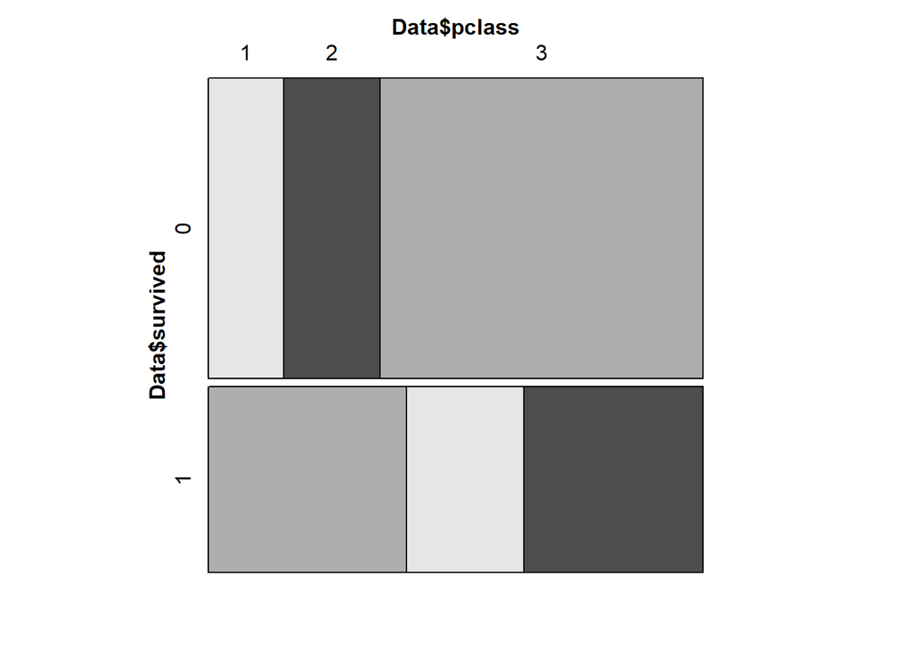

```r
mosaic(Data$pclass~Data$survived)
```

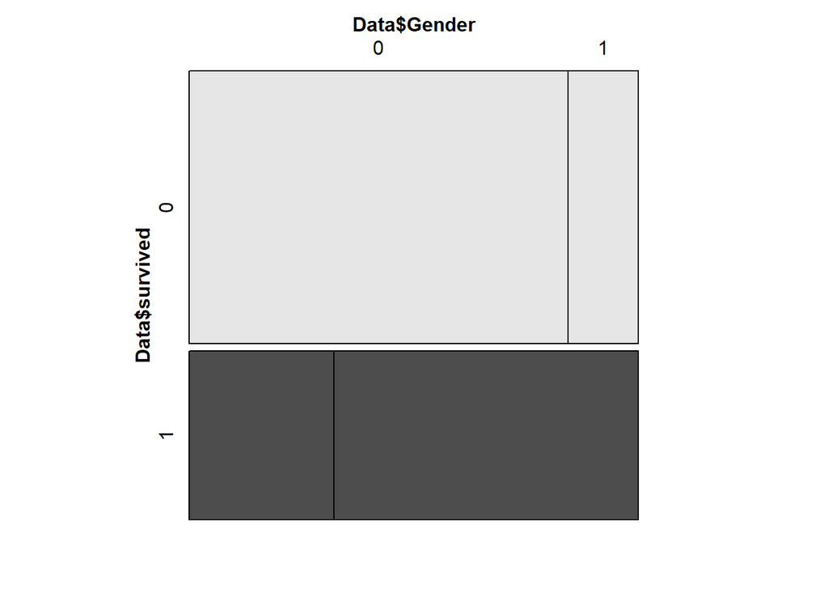

```r
mosaic(Data$Gender~Data$survived)
```

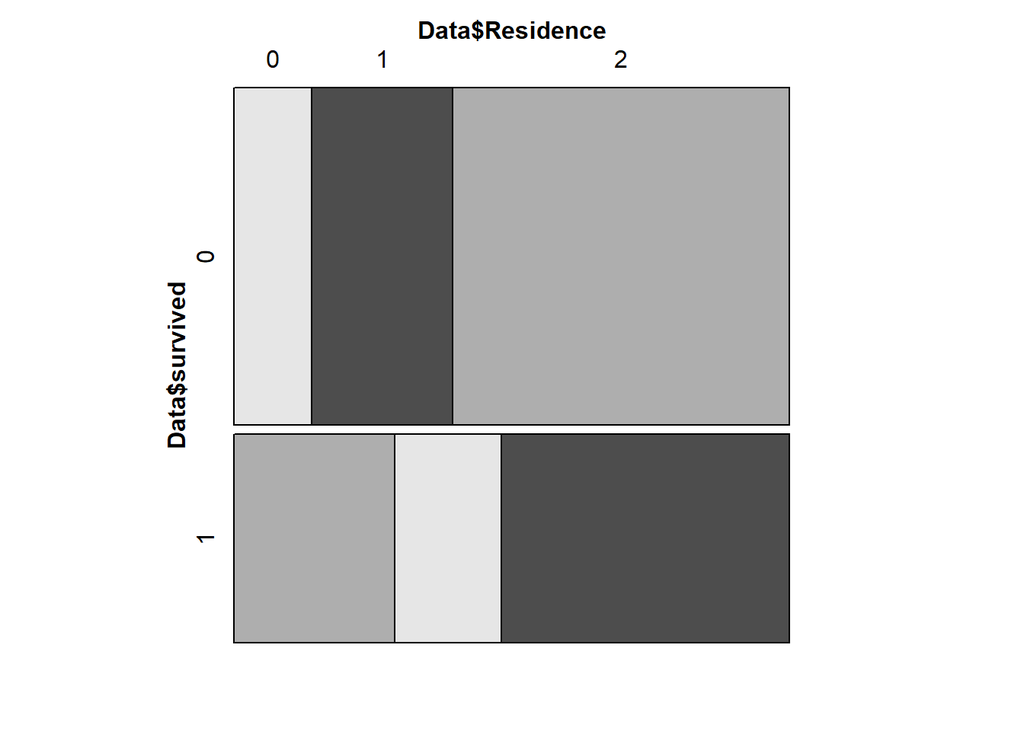

```r
mosaic(Data$Residence~Data$survived)
```

```r
library(popbio)
```

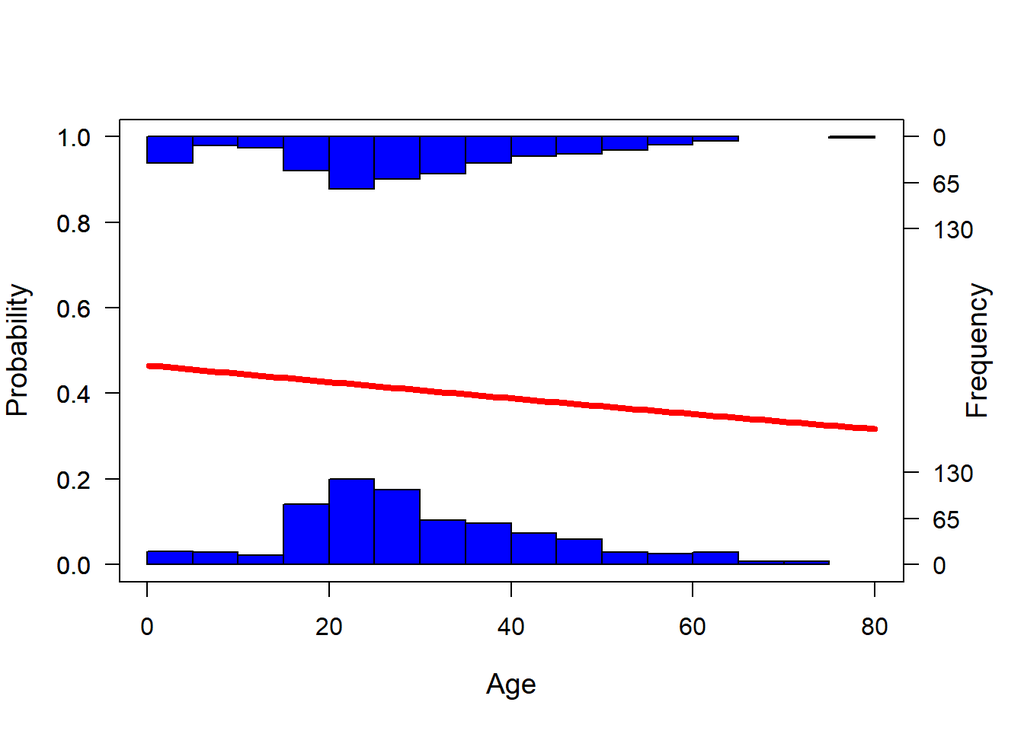

```r
Agenona<-na.omit(data.frame("Age"=Data$age,"Survived"=Data$survived))

FareNona<-na.omit(data.frame("Fare"=Data$fare,"Survived"=Data$survived))

logi.hist.plot(Agenona$Age,Agenona$Survived,boxp=FALSE,type="hist",col="blue", xlabel="Age")
```

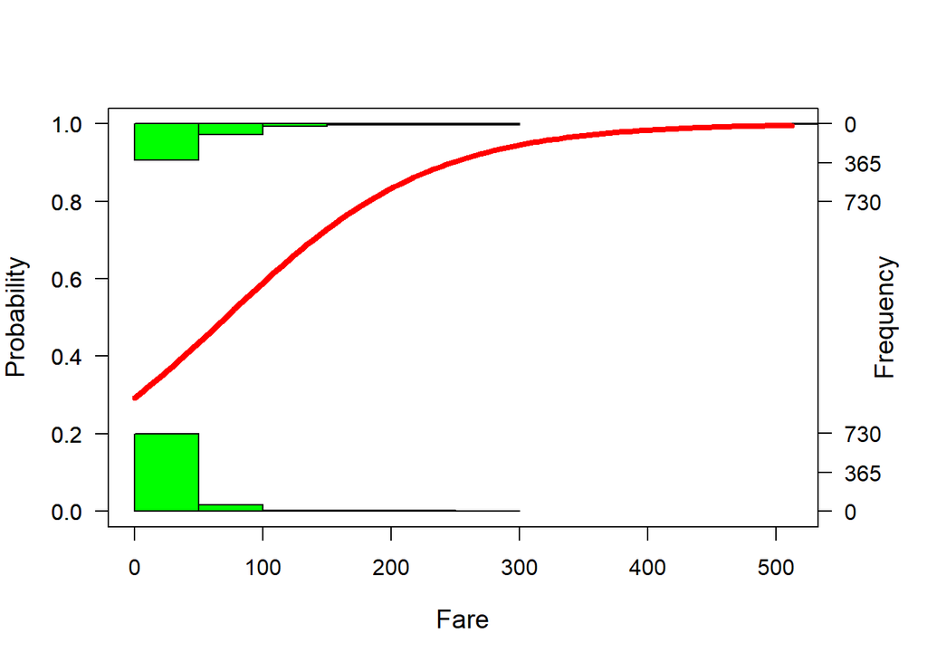

```r
logi.hist.plot(FareNona$Fare,FareNona$Survived,boxp=FALSE,type="hist",col="green", xlabel="Fare")
```

## 4. Automatic Selection

```r
library(dplyr)
library(bestglm)
Variables<-data.frame("Age"=Data$age,"Class"=Data$pclass,"Fare"=Data$fare,"Gender"=Data$Gender,"Residence"=Data$Residence, "Survived"=Data$survived) %>%
na.omit(Variables)

bestglm(Variables,IC="AIC",family=binomial)
```

```
## Morgan-Tatar search since family is non-gaussian.
```

```
## AIC
## BICq equivalent for q in (0.921097270259508, 0.967051542136449)
## Best Model:
##                Estimate  Std. Error   z value     Pr(>|z|)
## (Intercept)  2.17393350 0.377728131  5.755286 8.649512e-09
## Age         -0.03489377 0.006355926 -5.489958 4.020288e-08
## Class       -1.06393151 0.121072093 -8.787587 1.528070e-18
## Gender       2.51230338 0.166970795 15.046364 3.647371e-51
## Residence   -0.16088866 0.112728978 -1.427217 1.535175e-01
```

## 5. Logistic Regression

```r
Mod1<-glm(Survived~Age+Class+Gender+Residence, data=Variables)
summary.lm(Mod1)
```

```
##
## Call:
## glm(formula = Survived ~ Age + Class + Gender + Residence, data = Variables)
##
## Residuals:
##      Min       1Q   Median       3Q      Max
## -1.05901 -0.25500 -0.07965  0.22452  1.00808
##
## Coefficients:
##              Estimate Std. Error t value Pr(>|t|)
## (Intercept)  0.796488   0.058019  13.728  < 2e-16 ***
## Age         -0.005337   0.000936  -5.702 1.54e-08 ***
## Class       -0.172346   0.017837  -9.662  < 2e-16 ***
## Gender       0.492903   0.025572  19.276  < 2e-16 ***
## Residence   -0.023682   0.017247  -1.373     0.17
## ---
## Signif. codes:  0 '***' 0.001 '**' 0.01 '*' 0.05 '.' 0.1 ' ' 1
##
## Residual standard error: 0.3913 on 1040 degrees of freedom
## Multiple R-squared:  0.3693, Adjusted R-squared:  0.3669
## F-statistic: 152.3 on 4 and 1040 DF,  p-value: < 2.2e-16
```

## 6. Purposeful Selection

```r
GLMAge<-glm(Survived~Age, data=Variables, family=binomial(link="logit"))
summary(GLMAge)
```

```
##
## Call:
## glm(formula = Survived ~ Age, family = binomial(link = "logit"),
##     data = Variables)
##
## Deviance Residuals:
##     Min       1Q   Median       3Q      Max
## -1.1169  -1.0364  -0.9787   1.3186   1.5108
##
## Coefficients:
##              Estimate Std. Error z value Pr(>|z|)
## (Intercept) -0.141394   0.144839  -0.976   0.3290
## Age         -0.007687   0.004414  -1.742   0.0816 .
## ---
## Signif. codes:  0 '***' 0.001 '**' 0.01 '*' 0.05 '.' 0.1 ' ' 1
##
## (Dispersion parameter for binomial family taken to be 1)
##
##     Null deviance: 1413.6  on 1044  degrees of freedom
## Residual deviance: 1410.5  on 1043  degrees of freedom
## AIC: 1414.5
##
## Number of Fisher Scoring iterations: 4
```

```r
GLMClass<-glm(Survived~Class, data=Variables, family=binomial(link="logit"))
summary(GLMClass)
```

```
##
## Call:
## glm(formula = Survived ~ Class, family = binomial(link = "logit"),
##     data = Variables)
##
## Deviance Residuals:
##     Min       1Q   Median       3Q      Max
## -1.4238  -0.7793  -0.7793   0.9496   1.6370
##
## Coefficients:
##             Estimate Std. Error z value Pr(>|z|)
## (Intercept)  1.36234    0.18247   7.466 8.25e-14 ***
## Class       -0.79953    0.07954 -10.052  < 2e-16 ***
## ---
## Signif. codes:  0 '***' 0.001 '**' 0.01 '*' 0.05 '.' 0.1 ' ' 1
##
## (Dispersion parameter for binomial family taken to be 1)
##
##     Null deviance: 1413.6  on 1044  degrees of freedom
## Residual deviance: 1305.3  on 1043  degrees of freedom
## AIC: 1309.3
##
## Number of Fisher Scoring iterations: 4
```

```r
GLMFare<-glm(Survived~Fare, data=Variables, family=binomial(link="logit"))
summary(GLMFare)
```

```
##
## Call:
## glm(formula = Survived ~ Fare, family = binomial(link = "logit"),
##     data = Variables)
##
## Deviance Residuals:
##     Min       1Q   Median       3Q      Max
## -2.2308  -0.9284  -0.8981   1.3348   1.5278
##
## Coefficients:
##              Estimate Std. Error z value Pr(>|z|)
## (Intercept) -0.794094   0.084413  -9.407  < 2e-16 ***
## Fare         0.012150   0.001704   7.132 9.92e-13 ***
## ---
## Signif. codes:  0 '***' 0.001 '**' 0.01 '*' 0.05 '.' 0.1 ' ' 1
##
## (Dispersion parameter for binomial family taken to be 1)
##
##     Null deviance: 1413.6  on 1044  degrees of freedom
## Residual deviance: 1339.9  on 1043  degrees of freedom
## AIC: 1343.9
##
## Number of Fisher Scoring iterations: 4
```

```r
GLMGender<-glm(Survived~Gender, data=Variables, family=binomial(link="logit"))
summary(GLMGender)
```

```
##
## Call:
## glm(formula = Survived ~ Gender, family = binomial(link = "logit"),
##     data = Variables)
##
## Deviance Residuals:
##     Min       1Q   Median       3Q      Max
## -1.6713  -0.6783  -0.6783   0.7540   1.7790
##
## Coefficients:
##             Estimate Std. Error z value Pr(>|z|)
## (Intercept) -1.35239    0.09656  -14.01   <2e-16 ***
## Gender       2.46480    0.15220   16.20   <2e-16 ***
## ---
## Signif. codes:  0 '***' 0.001 '**' 0.01 '*' 0.05 '.' 0.1 ' ' 1
##
## (Dispersion parameter for binomial family taken to be 1)
##
##     Null deviance: 1413.6  on 1044  degrees of freedom
## Residual deviance: 1101.5  on 1043  degrees of freedom
## AIC: 1105.5
##
## Number of Fisher Scoring iterations: 4
```

```r
GLMResidence<-glm(Survived~Residence, data=Variables, family=binomial(link="logit"))
summary(GLMResidence)
```

```
##
## Call:
## glm(formula = Survived ~ Residence, family = binomial(link = "logit"),
##     data = Variables)
##
## Deviance Residuals:
##     Min       1Q   Median       3Q      Max
## -1.2333  -0.9207  -0.9207   1.2871   1.4579
##
## Coefficients:
##             Estimate Std. Error z value Pr(>|z|)
## (Intercept)  0.13047    0.11840   1.102    0.271
## Residence   -0.38466    0.07768  -4.952 7.35e-07 ***
## ---
## Signif. codes:  0 '***' 0.001 '**' 0.01 '*' 0.05 '.' 0.1 ' ' 1
##
## (Dispersion parameter for binomial family taken to be 1)
##
##     Null deviance: 1413.6  on 1044  degrees of freedom
## Residual deviance: 1388.8  on 1043  degrees of freedom
## AIC: 1392.8
##
## Number of Fisher Scoring iterations: 4
```

All variables have a p < 0.25

```r
Mod2<-glm(Survived~Age+Class+Fare+Gender+Residence, data=Variables, family=binomial(link="logit"))
summary(Mod2)
```

```
##
## Call:
## glm(formula = Survived ~ Age + Class + Fare + Gender + Residence,
##     family = binomial(link = "logit"), data = Variables)
##
## Deviance Residuals:
##     Min       1Q   Median       3Q      Max
## -2.5734  -0.7020  -0.4275   0.6627   2.4315
##
## Coefficients:
##               Estimate Std. Error z value Pr(>|z|)
## (Intercept)  2.0856446  0.4280749   4.872 1.10e-06 ***
## Age         -0.0347436  0.0063670  -5.457 4.85e-08 ***
## Class       -1.0350039  0.1378180  -7.510 5.92e-14 ***
## Fare         0.0007536  0.0017249   0.437    0.662
## Gender       2.5045814  0.1677994  14.926  < 2e-16 ***
## Residence   -0.1629428  0.1129600  -1.442    0.149
## ---
## Signif. codes:  0 '***' 0.001 '**' 0.01 '*' 0.05 '.' 0.1 ' ' 1
##
## (Dispersion parameter for binomial family taken to be 1)
##
##     Null deviance: 1413.57  on 1044  degrees of freedom
## Residual deviance:  980.73  on 1039  degrees of freedom
## AIC: 992.73
##
## Number of Fisher Scoring iterations: 4
```

Dropping Fare as it is not signficant and comapring models:

```r
Mod3<-glm(Survived~Age+Class+Gender+Residence, data=Variables, family=binomial(link="logit"))
summary(Mod3)
```

```
##
## Call:
## glm(formula = Survived ~ Age + Class + Gender + Residence, family = binomial(link = "logit"),
##     data = Variables)
##
## Deviance Residuals:
##     Min       1Q   Median       3Q      Max
## -2.5572  -0.7090  -0.4300   0.6642   2.4343
##
## Coefficients:
##              Estimate Std. Error z value Pr(>|z|)
## (Intercept)  2.173934   0.377728   5.755 8.65e-09 ***
## Age         -0.034894   0.006356  -5.490 4.02e-08 ***
## Class       -1.063932   0.121072  -8.788  < 2e-16 ***
## Gender       2.512303   0.166971  15.046  < 2e-16 ***
## Residence   -0.160889   0.112729  -1.427    0.154
## ---
## Signif. codes:  0 '***' 0.001 '**' 0.01 '*' 0.05 '.' 0.1 ' ' 1
##
## (Dispersion parameter for binomial family taken to be 1)
##
##     Null deviance: 1413.57  on 1044  degrees of freedom
## Residual deviance:  980.92  on 1040  degrees of freedom
## AIC: 990.92
##
## Number of Fisher Scoring iterations: 4
```

```r
library(lmtest)
lrtest(Mod2,Mod3)
```

```
## Likelihood ratio test
##
## Model 1: Survived ~ Age + Class + Fare + Gender + Residence
## Model 2: Survived ~ Age + Class + Gender + Residence
##   #Df  LogLik Df  Chisq Pr(>Chisq)
## 1   6 -490.36
## 2   5 -490.46 -1 0.1932     0.6603
```

P > 0.05 which indicates that the two models are not signficantly different in their predictive ability. So let’s remove Residence and try again.

```r
Mod4<-glm(Survived~Age+Class+Gender, data=Variables, family=binomial(link="logit"))
summary(Mod4)
```

```
##
## Call:
## glm(formula = Survived ~ Age + Class + Gender, family = binomial(link = "logit"),
##     data = Variables)
##
## Deviance Residuals:
##     Min       1Q   Median       3Q      Max
## -2.6150  -0.7178  -0.4323   0.6570   2.4034
##
## Coefficients:
##              Estimate Std. Error z value Pr(>|z|)
## (Intercept)  2.089113   0.371597   5.622 1.89e-08 ***
## Age         -0.033833   0.006285  -5.383 7.33e-08 ***
## Class       -1.132460   0.111779 -10.131  < 2e-16 ***
## Gender       2.496811   0.166120  15.030  < 2e-16 ***
## ---
## Signif. codes:  0 '***' 0.001 '**' 0.01 '*' 0.05 '.' 0.1 ' ' 1
##
## (Dispersion parameter for binomial family taken to be 1)
##
##     Null deviance: 1413.57  on 1044  degrees of freedom
## Residual deviance:  982.96  on 1041  degrees of freedom
## AIC: 990.96
##
## Number of Fisher Scoring iterations: 4
```

```r
lrtest(Mod3,Mod4)
```

```
## Likelihood ratio test
##
## Model 1: Survived ~ Age + Class + Gender + Residence
## Model 2: Survived ~ Age + Class + Gender
##   #Df  LogLik Df  Chisq Pr(>Chisq)
## 1   5 -490.46
## 2   4 -491.48 -1 2.0371     0.1535
```

Mod 3 and mod 4 are not sigificantly different in their predictive ability. In mod4 all of the variables are pretty sigificant, but lets try removing one more.

```r
Mod5<-glm(Survived~Class+Gender, data=Variables, family=binomial(link="logit"))
summary(Mod5)
```

```
##
## Call:
## glm(formula = Survived ~ Class + Gender, family = binomial(link = "logit"),
##     data = Variables)
##
## Deviance Residuals:
##     Min       1Q   Median       3Q      Max
## -2.1242  -0.7138  -0.4821   0.6977   2.1024
##
## Coefficients:
##             Estimate Std. Error z value Pr(>|z|)
## (Intercept)  0.47554    0.21333   2.229   0.0258 *
## Class       -0.85646    0.09512  -9.004   <2e-16 ***
## Gender       2.52634    0.16326  15.474   <2e-16 ***
## ---
## Signif. codes:  0 '***' 0.001 '**' 0.01 '*' 0.05 '.' 0.1 ' ' 1
##
## (Dispersion parameter for binomial family taken to be 1)
##
##     Null deviance: 1413.6  on 1044  degrees of freedom
## Residual deviance: 1013.6  on 1042  degrees of freedom
## AIC: 1019.6
##
## Number of Fisher Scoring iterations: 4
```

```r
lrtest(Mod4,Mod5)
```

```
## Likelihood ratio test
##
## Model 1: Survived ~ Age + Class + Gender
## Model 2: Survived ~ Class + Gender
##   #Df  LogLik Df  Chisq Pr(>Chisq)
## 1   4 -491.48
## 2   3 -506.81 -1 30.658  3.077e-08 ***
## ---
## Signif. codes:  0 '***' 0.001 '**' 0.01 '*' 0.05 '.' 0.1 ' ' 1
```

In this case there is a sigificant difference in the predictive ability of models 4 and 5. Therefor I will conclude that model 4 is the minimum adaquate model for this data set.

## 7. Purposeful selection of variables lead to the creation of a model including one variable fewer than suggested through automatic selection.

Mod1<-glm(Survived~Age+Class+Gender+Residence, data=Variables) Mod4<-glm(Survived~Age+Class+Gender, data=Variables, family=binomial(link=“logit”))

## 8. View effects.

Following the principle of parsimony, I selected Mod4 as my best model due to the inclusion of fewer variables.

```r
library(effects)
```

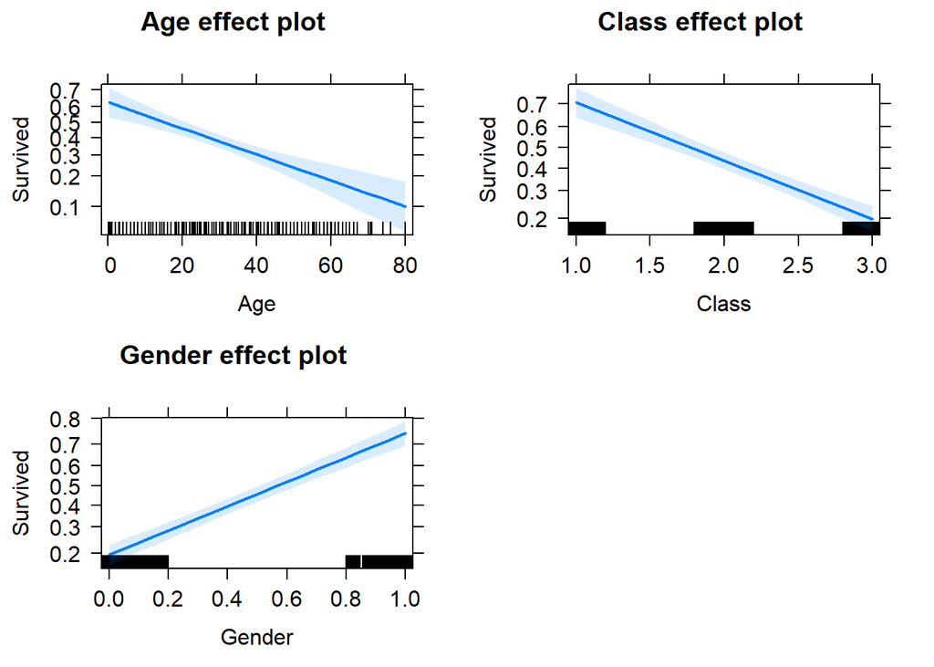

```r
plot(allEffects(Mod4))
```

All the effects included in Model 4 are in the direction that I expected.

## 9.Regression Diagnostics

```r
library(car)
```

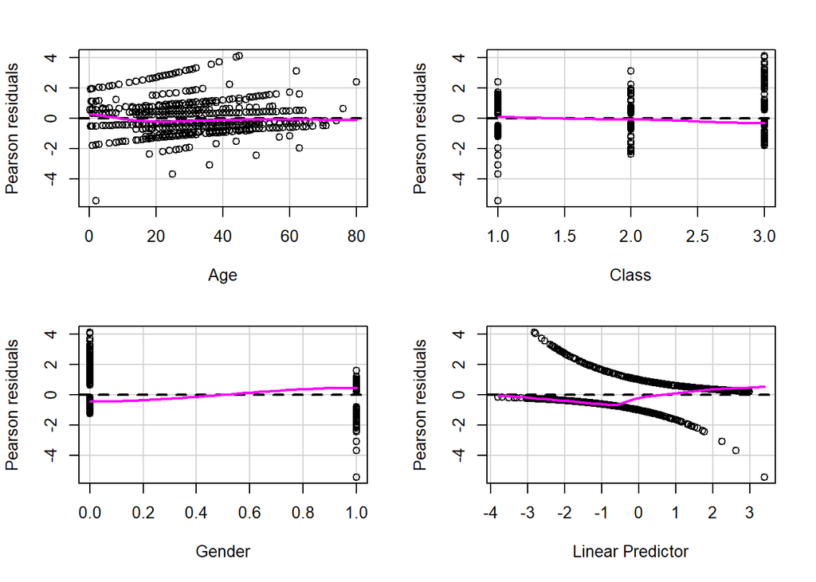

```
##        Test stat Pr(>|Test stat|)
## Age       1.8165           0.1777
## Class     0.5720           0.4494
## Gender    0.0000           1.0000
```

```r
residualPlots(Mod4)
```

Now testing for outliers…

```r
outlierTest(Mod4)
```

```
## No Studentized residuals with Bonferroni p < 0.05
## Largest |rstudent|:
##    rstudent unadjusted p-value Bonferroni p
## 25 -2.63147          0.0085016           NA
```

This indicates that there are no sigificant outliers in the data as there are no studentized residuals with Bonferroni p < 0.05

Now lets test for leverage:

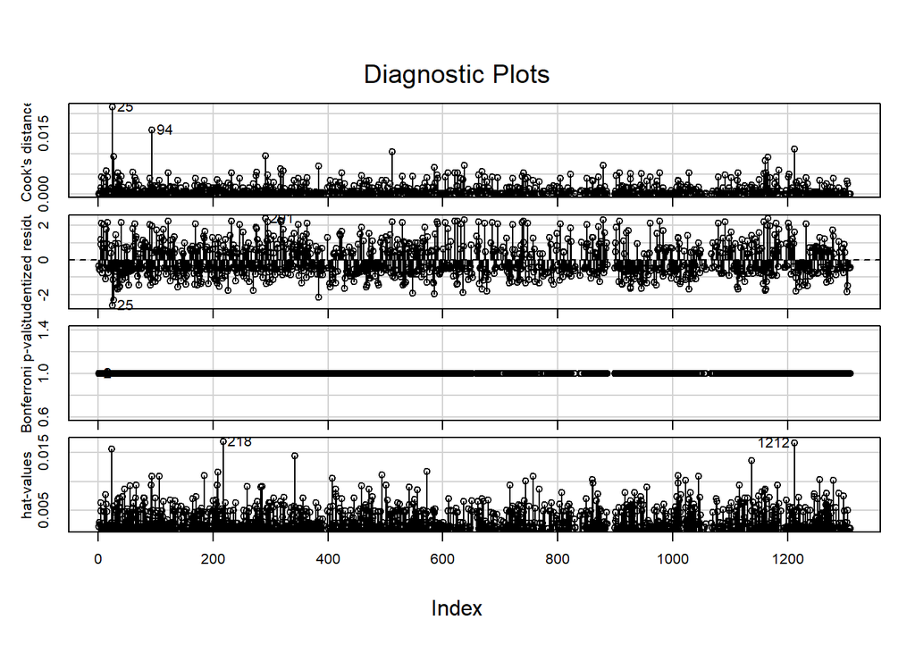

```r
influenceIndexPlot(Mod4, id.n=3)
```

All bonferreni p values are close to 1 indicating that there is no sigificant differneces in the leverage of model points

Now testing for influence (Cook’s distance):

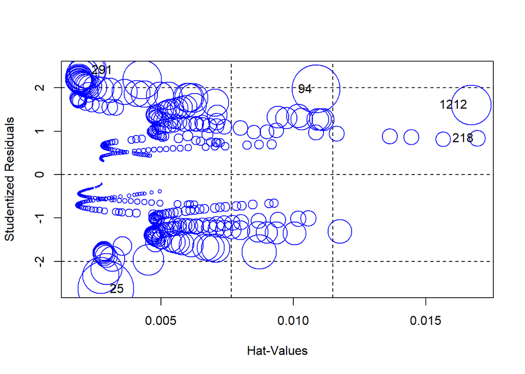

```
##         StudRes         Hat       CookD
## 25   -2.6314704 0.002918114 0.021677762
## 94    1.9706584 0.010845630 0.015946656
## 218   0.8365479 0.016940146 0.001813741
## 291   2.4112418 0.002236418 0.009523872
## 1212  1.6085152 0.016700530 0.011086755
```

```r
influencePlot(Mod4, col="blue")
```

Now we’ll try removing the point with the largest Cook’s distance and comparing the models:

```r
Mod4b<-update(Mod4,subset=c(-25))
compareCoefs(Mod4,Mod4b)
```

```
## Calls:
## 1: glm(formula = Survived ~ Age + Class + Gender, family = binomial(link =
##   "logit"), data = Variables)
## 2: glm(formula = Survived ~ Age + Class + Gender, family = binomial(link =
##   "logit"), data = Variables, subset = c(-25))
##
##              Model 1  Model 2
## (Intercept)    2.089    2.186
## SE             0.372    0.375
##
## Age         -0.03383 -0.03533
## SE           0.00629  0.00634
##
## Class         -1.132   -1.158
## SE             0.112    0.113
##
## Gender         2.497    2.519
## SE             0.166    0.167
##
```

The coefficients have changed very little between the models indicating that point 25 is not influencial on our model.

Now let’s check for multicolinearity:

```r
vif(Mod4)
```

```
##      Age    Class   Gender
## 1.335285 1.396301 1.053015
```

All VIF values are below 4 indicating that there is no multicoliarity of concern in Mod4.

Now we’ll summarize everything with the print function:

```r
print(Mod4)
```

```
##
## Call:  glm(formula = Survived ~ Age + Class + Gender, family = binomial(link = "logit"),
##     data = Variables)
##
## Coefficients:
## (Intercept)          Age        Class       Gender
##     2.08911     -0.03383     -1.13246      2.49681
##
## Degrees of Freedom: 1044 Total (i.e. Null);  1041 Residual
## Null Deviance:       1414
## Residual Deviance: 983   AIC: 991
```

## 11. k-fold cross validation - how good is our model at predicting survival?

```r
library(caret)
ctrl <- trainControl(method = "repeatedcv", number = 10, savePredictions = TRUE)

Variables$Survived=as.factor(Variables$Survived)

train(Survived~Age + Class + Gender,data=Variables, method="glm", family=binomial(link='logit'),
                 trControl = ctrl, tuneLength = 5)
```

```
## Generalized Linear Model
##
## 1045 samples
##    3 predictor
##    2 classes: '0', '1'
##
## No pre-processing
## Resampling: Cross-Validated (10 fold, repeated 1 times)
## Summary of sample sizes: 941, 940, 942, 940, 940, 941, ...
## Resampling results:
##
##   Accuracy   Kappa
##   0.7809858  0.5411571
```

## 12. K-fold Model Accuracy

Based on the k-fold results, Mod4 was accurate at predicting survival ~78% of the time

## 13. Confusion Matrix

```r
Predictions<-predict(Mod4, newdata=Variables,type="response")

confusionMatrix(table(data=as.numeric(Predictions>0.5),reference=Variables$Survived))
```

```
## Confusion Matrix and Statistics
##
##     reference
## data   0   1
##    0 522 126
##    1  96 301
##
##                Accuracy : 0.7876
##                  95% CI : (0.7615, 0.812)
##     No Information Rate : 0.5914
##     P-Value [Acc > NIR] : < 2e-16
##
##                   Kappa : 0.5556
##
##  Mcnemar's Test P-Value : 0.05161
##
##             Sensitivity : 0.8447
##             Specificity : 0.7049
##          Pos Pred Value : 0.8056
##          Neg Pred Value : 0.7582
##              Prevalence : 0.5914
##          Detection Rate : 0.4995
##    Detection Prevalence : 0.6201
##       Balanced Accuracy : 0.7748
##
##        'Positive' Class : 0
##
```